# Station clock screen of every station, catalog v5.1 residuals (D-B090)

Detector output: `detect_full`. Sign convention: c(t) = header time - true time (s); positive = picks late; clock_correction_s = -c(t) is added to the pick time. Candidates other than MH07.XD and MG07.XD are for review by the PI; nothing else is applied.

## 1. Screen

693 stations; 582 screened (enough picks and bins); 115 with candidate epochs, 131 candidate epochs in total; 2 of them are covered by confirmed epochs.

| net | stations | screened | candidates | picks |
| --- | --- | --- | --- | --- |
| 7A | 9 | 2 | 0 | 455 |
| 7D | 233 | 184 | 24 | 236030 |
| BK | 3 | 3 | 1 | 24512 |
| C8 | 9 | 5 | 0 | 2722 |
| CC | 12 | 12 | 3 | 44977 |
| CN | 28 | 27 | 5 | 107224 |
| GS | 1 | 0 | 0 | 4 |
| NC | 39 | 34 | 9 | 154169 |
| NV | 5 | 5 | 0 | 3099 |
| OO | 13 | 13 | 6 | 251048 |
| PB | 46 | 46 | 9 | 455427 |
| TA | 25 | 24 | 2 | 100511 |
| UO | 9 | 5 | 1 | 7280 |
| UW | 92 | 85 | 14 | 283487 |
| X4 | 4 | 3 | 0 | 644 |
| X9 | 30 | 30 | 9 | 229649 |
| XD | 47 | 46 | 9 | 209503 |
| XG | 20 | 0 | 0 | 1470 |
| XU | 4 | 4 | 0 | 5678 |
| YG | 1 | 0 | 0 | 25 |
| YH | 12 | 11 | 0 | 14923 |
| YW | 9 | 6 | 0 | 2266 |
| Z5 | 40 | 37 | 23 | 147384 |
| ZZ | 2 | 0 | 0 | 185 |

## 2. False alarms and detection power

Same detector (pre-screen, permutation test, thresholds) on stations without a clock problem: synthetic stations with each real station's pick times and noise level, and each real station with its residuals shuffled in time. Injection: drifts (rate s/day : duration days) added to shuffled real data; recovered = flagged as a drift with the start within 25 % of the duration and the rate within 50 %.

| run | stations | flagged | rate | 95 % upper | T 95th pct | T max | recovery |
| --- | --- | --- | --- | --- | --- | --- | --- |
| inject:0.004:60 | 578 | 250 | 0.4325 |  |  |  | 0.369 |
| inject:0.008:90 | 575 | 442 | 0.7687 |  |  |  | 0.732 |
| permuted | 582 | 1 | 0.0017 | 0.0081 | 5.3 | 32.8 |  |
| synthetic | 1164 | 0 | 0.0000 | 0.0026 | 3.8 | 31.1 |  |

Thresholds: {"dbic_min": 30.0, "amp_min_s": 0.05, "p_max": 0.01, "n_perm": 200, "neighbor_km": 100.0, "min_picks": 60}

## 3. Candidate epochs

evidence: **colocated** = pairs of nearby events inside/outside the epoch show the same jump (a clock survives the pair difference, a change in the event mix does not); **P=S** = P and S move by the same amount; **reset@restart** = the epoch ends at a MiniSEED data restart; **CC** = cross-correlation differential times confirm the size. A person decides.

| candidate_id | model | t_start_utc | t_end_utc | a | a_units | amp_s | dbic | p_perm | cc_a | a_P | a_S | coloc_ratio | coloc_n | reset_at_restart | evidence | confirmed |
| --- | --- | --- | --- | --- | --- | --- | --- | --- | --- | --- | --- | --- | --- | --- | --- | --- |
| AXEC2.OO#1 | offset_epoch | 2014-12-13T15:18:05Z | 2015-01-15T19:18:04Z | -0.6729 | s | 0.6729 | 3490 | 0.004975 | NaN | -0.3855 | -0.728 | 0.8338 | 666 | NaN | clock-like [colocated,P=S] | False |
| MH07.XD#1 | drift_reset | 2016-02-07T14:15:50Z | 2016-05-06T13:48:37Z | 0.006833 | s/day | 0.608 | 1048 | 0.004975 | 0.008474 | 0.006753 | 0.006931 | 1.042 | 1123 | NaN | clock-like [colocated,P=S,CC] | True |
| AXAS2.OO#1 | offset_epoch | 2014-12-13T04:55:45Z | 2014-12-16T11:33:13Z | -0.1139 | s | 0.1139 | 494.3 | 0.004975 | NaN | -0.1067 | -0.119 | 0.8289 | 1792 | NaN | clock-like [colocated,P=S] | False |
| GB331.Z5#1 | drift_reset | 2014-11-06T21:31:27Z | 2015-08-29T19:06:45Z | 0.001719 | s/day | 0.5087 | 493.2 | 0.004975 | NaN | 0.00202 | 0.001505 | 1.309 | 5135 | NaN | clock-like [colocated,P=S] | False |
| AXCC1.OO#1 | offset_epoch | 2014-12-14T00:06:43Z | 2014-12-16T11:33:13Z | 0.248 | s | 0.248 | 463.5 | 0.004975 | NaN | 0.2982 | 0.1262 | 0.8221 | 1073 | NaN | unclear [colocated] | False |
| BB830.Z5#1 | drift_reset | 2014-10-11T01:24:25Z | 2015-08-28T19:35:40Z | 0.001405 | s/day | 0.452 | 450.9 | 0.004975 | NaN | 0.001843 | 0.0004711 | 1.322 | 8726 | NaN | unclear [colocated] | False |
| G37B.7D#1 | drift_open | 2012-10-03T09:05:29Z | NaN | 0.002514 | s/day | 0.6536 | 432.6 | 0.004975 | NaN | 0.002572 | 0.002335 | 1.044 | 2219 | NaN | clock-like [colocated,P=S] | False |
| AXID1.OO#1 | drift_reset | 2015-04-22T19:48:11Z | 2015-05-18T14:58:32Z | 0.01642 | s/day | 0.4236 | 423.2 | 0.004975 | NaN | 0.01517 | 0.00496 | 0.4206 | 4917 | NaN | unclear | False |
| MG07.XD#1 | drift_reset | 2016-02-12T23:52:22Z | 2016-05-10T15:07:40Z | -0.003846 | s/day | 0.337 | 408.3 | 0.004975 | -0.003964 | -0.003572 | -0.004053 | 0.9361 | 1099 | NaN | clock-like [colocated,P=S,CC] | True |
| BB370.X9#1 | offset_epoch | 2012-10-02T08:06:47Z | 2012-10-12T18:56:43Z | -0.1276 | s | 0.1276 | 365.8 | 0.004975 | NaN | -0.1155 | -0.132 | -0.07482 | 5333 | NaN | unclear [P=S] {colocated~0} | False |
| BB230.X9#1 | offset_epoch | 2012-10-01T21:07:32Z | 2012-10-04T07:36:59Z | 0.5298 | s | 0.5298 | 326 | 0.004975 | NaN | 0.3746 | 0.7103 | 0.06099 | 315 | NaN | unclear [P=S] {colocated~0} | False |
| AXEC2.OO#2 | drift_reset | 2014-12-12T01:43:48Z | 2015-01-04T08:18:46Z | -0.02305 | s/day | 0.5366 | 323.4 | 0.004975 | NaN | 0.005445 | -0.02684 | 0.5407 | 2113 | NaN | unclear [colocated] {P/S opposite} | False |
| J06B.7D#1 | offset_epoch | 2012-10-02T12:38:51Z | 2012-10-08T18:35:28Z | -0.2512 | s | 0.2512 | 304.1 | 0.004975 | NaN | -0.08874 | -0.2874 | 0.01727 | 1841 | NaN | event-mix-like {colocated~0} | False |
| BB290.X9#1 | offset_epoch | 2012-10-02T15:22:38Z | 2012-10-06T07:08:43Z | 0.3792 | s | 0.3792 | 293.9 | 0.004975 | NaN | 0.2475 | 0.4131 | -0.07336 | 509 | NaN | unclear [P=S] {colocated~0} | False |
| BB350.X9#1 | offset_epoch | 2012-09-30T05:26:28Z | 2012-10-16T01:29:18Z | 0.1838 | s | 0.1838 | 280.3 | 0.004975 | NaN | 0.05283 | 0.4439 | -0.127 | 6397 | NaN | event-mix-like {colocated~0} | False |
| AXEC1.OO#1 | offset_epoch | 2014-12-13T22:21:32Z | 2014-12-16T10:58:45Z | -0.08326 | s | 0.08326 | 273.3 | 0.004975 | NaN | -0.08425 | -0.089 | 0.8966 | 1434 | NaN | clock-like [colocated,P=S] | False |
| BB740.Z5#1 | offset_epoch | 2014-03-11T18:07:53Z | 2014-03-27T18:52:54Z | -0.1165 | s | 0.1165 | 229.2 | 0.004975 | NaN | -0.08024 | -0.1567 | -0.1237 | 4382 | NaN | unclear [P=S] {colocated~0} | False |
| BB730.Z5#1 | offset_epoch | 2014-03-11T02:15:14Z | 2014-03-27T18:52:46Z | 0.136 | s | 0.136 | 229 | 0.004975 | NaN | 0.1006 | 0.1741 | 0.1239 | 4480 | NaN | unclear [P=S] {colocated~0} | False |
| KCT.NC#2 | offset_epoch | 2012-09-16T06:21:26Z | 2013-05-16T09:54:31Z | -0.09521 | s | 0.09521 | 204.3 | 0.004975 | NaN | -0.06878 | -0.1381 | 1.013 | 5911 | NaN | unclear [colocated] | False |
| YACT.UW#1 | step | 2014-07-14T13:55:01Z | NaN | 0.07747 | s | 0.07747 | 195 | 0.004975 | NaN | 0.06429 | 0.07953 | 0.8428 | 5267 | NaN | clock-like [colocated,P=S] | False |
| BB670.Z5#1 | offset_epoch | 2014-03-11T19:00:34Z | 2014-03-18T04:26:53Z | 0.1553 | s | 0.1553 | 183.4 | 0.004975 | NaN | 0.07006 | 0.2971 | -0.2356 | 1384 | NaN | event-mix-like {colocated~0} | False |
| KCT.NC#1 | offset_epoch | 2014-07-23T11:00:23Z | 2015-07-17T00:43:43Z | -0.09002 | s | 0.09002 | 183 | 0.004975 | NaN | -0.05593 | -0.1545 | 0.8042 | 8865 | NaN | unclear [colocated] | False |
| AXEC3.OO#1 | drift_reset | 2014-12-13T23:42:33Z | 2016-06-27T09:53:36Z | -0.0001347 | s/day | 0.07564 | 183 | 0.004975 | NaN | -0.0001219 | -0.0001577 | 0.5067 | 118610 | NaN | clock-like [colocated,P=S] | False |
| BB660.Z5#1 | offset_epoch | 2014-03-11T18:53:36Z | 2014-03-15T01:50:41Z | 0.2411 | s | 0.2411 | 159.4 | 0.004975 | NaN | 0.07413 | 0.5717 | 0.04635 | 557 | NaN | event-mix-like {colocated~0} | False |
| EDM.UW#1 | step | 2013-10-19T00:34:55Z | NaN | 0.09733 | s | 0.09733 | 157.5 | 0.004975 | -0.00234 | 0.08625 | 0.1101 | 0.6712 | 10628 | NaN | unclear [colocated,P=S] {CC~0} | False |
| G04D.7D#1 | step | 2014-12-14T16:54:20Z | NaN | -0.206 | s | 0.206 | 156.8 | 0.004975 | NaN | -0.1576 | -0.2736 | 1.048 | 2919 | NaN | clock-like [colocated,P=S] | False |
| BB710.Z5#1 | offset_epoch | 2014-02-01T22:19:45Z | 2014-02-04T08:34:58Z | -0.303 | s | 0.303 | 150 | 0.004975 | NaN | -0.2106 | -0.6389 | 0.08826 | 541 | NaN | event-mix-like {colocated~0} | False |
| B049.PB#1 | offset_epoch | 2014-03-10T05:35:04Z | 2014-03-21T11:01:12Z | 0.1097 | s | 0.1097 | 147.8 | 0.004975 | NaN | 0.01606 | 0.2166 | -0.09746 | 2024 | NaN | event-mix-like {colocated~0} | False |
| B201.PB#1 | step | 2010-02-19T16:04:06Z | NaN | -0.281 | s | 0.281 | 136.8 | 0.004975 | NaN | -0.4434 | -0.2149 | 2.388 | 3642 | NaN | unclear | False |
| GB101.Z5#1 | offset_epoch | 2015-04-23T10:29:28Z | 2015-05-05T16:51:58Z | 0.3789 | s | 0.3789 | 135.4 | 0.004975 | NaN | 0.2802 | 0.494 | -0.1342 | 562 | NaN | unclear [P=S] {colocated~0} | False |

[output cut: 101 more lines]

## 4. Per candidate

### AXEC2.OO#1 to review

clock-like [colocated,P=S]; start 2014-12-13T15:18:05Z (sd 0.01 d), end 2015-01-15T19:18:04Z [2015-01-15T18:36:56Z .. 2015-01-15T19:59:11Z], restart nan; size -0.67291 +- 0.073 s (residuals), CC +nan +- nan (n=0); dBIC 3489.9, p 0.00498

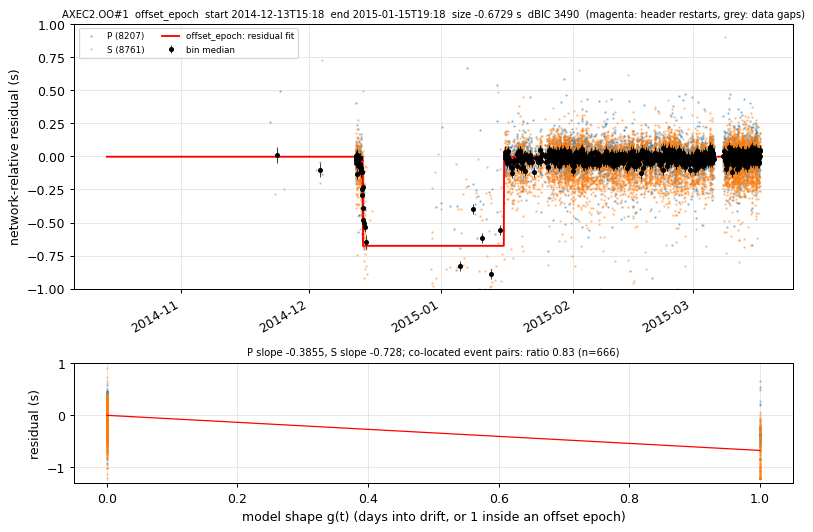

### MH07.XD#1 confirmed (see confirmed epochs)

clock-like [colocated,P=S,CC]; start 2016-02-07T14:15:50Z (sd 2.09 d), end 2016-05-06T13:48:37Z [2016-05-05T23:37:08Z .. 2016-05-07T04:00:07Z], restart nan; size +0.0068326 +- 0.00032 s/day (residuals), CC +0.0084736 +- 0.00027 (n=45); dBIC 1048.1, p 0.00498

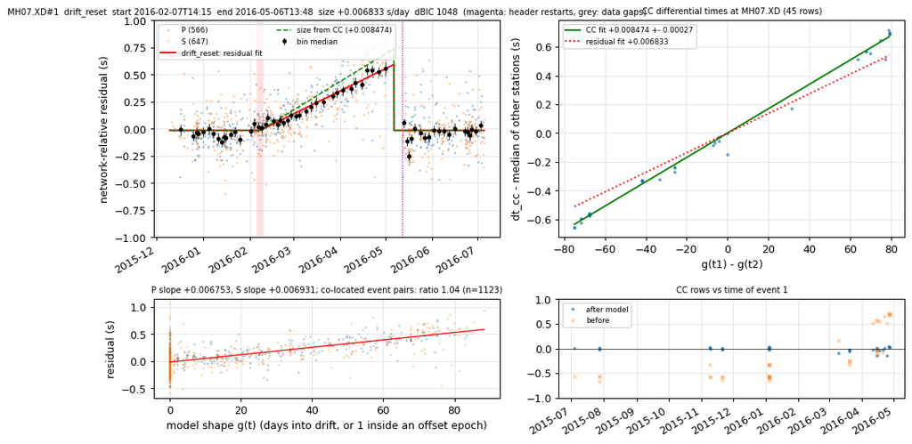

### AXAS2.OO#1 to review

clock-like [colocated,P=S]; start 2014-12-13T04:55:45Z (sd 0.00 d), end 2014-12-16T11:33:13Z [2014-12-16T11:33:11Z .. 2014-12-16T11:33:15Z], restart nan; size -0.11387 +- 0.008 s (residuals), CC +nan +- nan (n=0); dBIC 494.3, p 0.00498

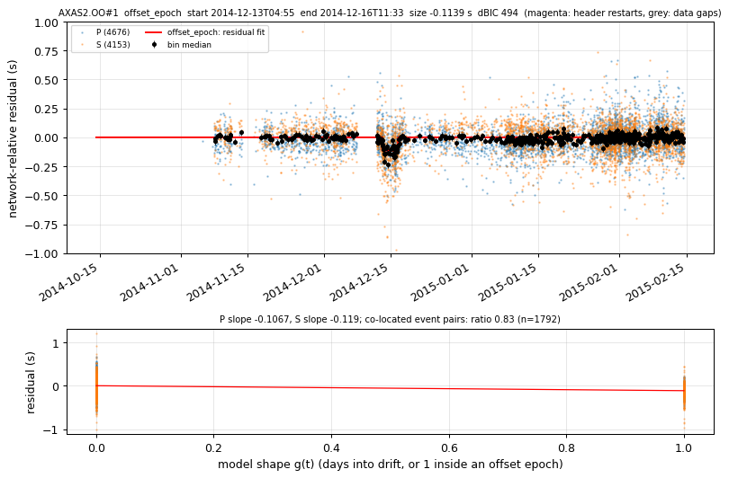

### GB331.Z5#1 to review

clock-like [colocated,P=S]; start 2014-11-06T21:31:27Z (sd 14.97 d), end 2015-08-29T19:06:45Z [2015-08-29T18:36:05Z .. 2015-08-29T19:37:26Z], restart nan; size +0.0017191 +- 0.0001 s/day (residuals), CC +nan +- nan (n=0); dBIC 493.2, p 0.00498

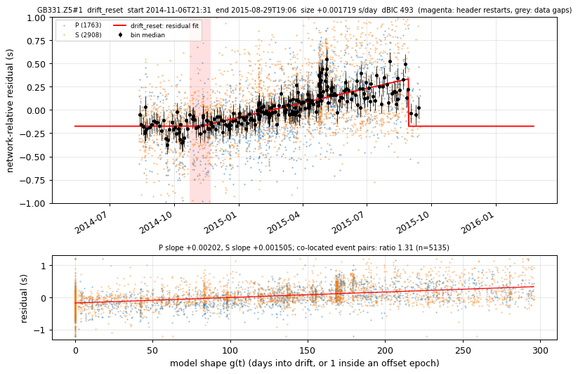

### AXCC1.OO#1 to review

unclear [colocated]; start 2014-12-14T00:06:43Z (sd 0.03 d), end 2014-12-16T11:33:13Z [2014-12-16T11:33:12Z .. 2014-12-16T11:33:15Z], restart nan; size +0.24804 +- 0.026 s (residuals), CC +nan +- nan (n=0); dBIC 463.5, p 0.00498

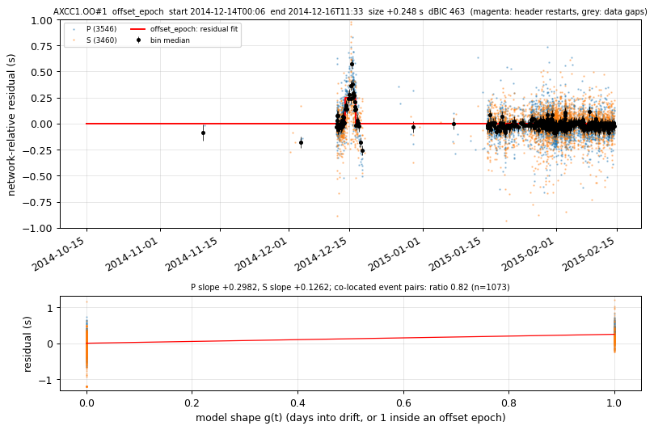

### BB830.Z5#1 to review

unclear [colocated]; start 2014-10-11T01:24:25Z (sd 10.78 d), end 2015-08-28T19:35:40Z [2015-08-28T19:26:23Z .. 2015-08-28T19:44:56Z], restart nan; size +0.0014049 +- 8.6e-05 s/day (residuals), CC +nan +- nan (n=0); dBIC 450.9, p 0.00498

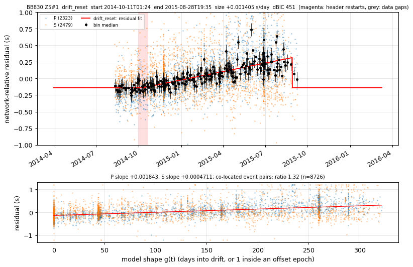

### G37B.7D#1 to review

clock-like [colocated,P=S]; start 2012-10-03T09:05:29Z (sd 13.14 d), end nan [nan .. nan], restart nan; size +0.0025139 +- 0.00015 s/day (residuals), CC +nan +- nan (n=0); dBIC 432.6, p 0.00498

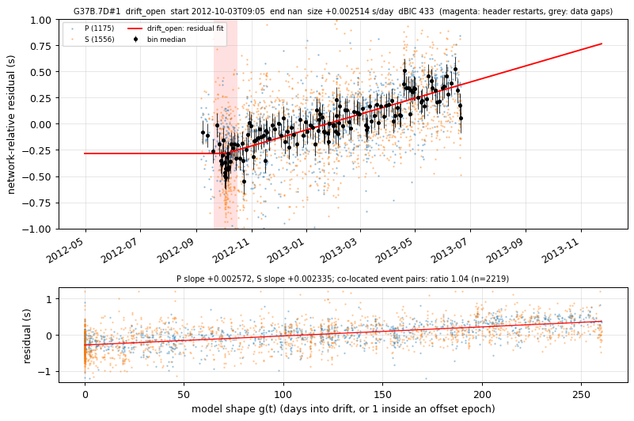

### AXID1.OO#1 to review

unclear; start 2015-04-22T19:48:11Z (sd 1.72 d), end 2015-05-18T14:58:32Z [2015-05-18T14:58:32Z .. 2015-05-18T14:58:32Z], restart nan; size +0.016418 +- 0.0036 s/day (residuals), CC +nan +- nan (n=0); dBIC 423.2, p 0.00498

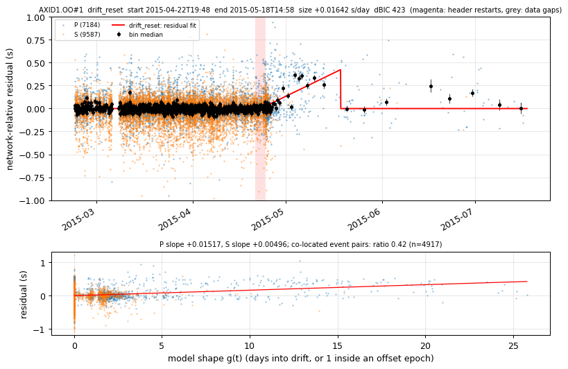

### MG07.XD#1 confirmed (see confirmed epochs)

clock-like [colocated,P=S,CC]; start 2016-02-12T23:52:22Z (sd 4.28 d), end 2016-05-10T15:07:40Z [2016-05-10T15:07:37Z .. 2016-05-10T15:07:43Z], restart nan; size -0.0038457 +- 0.0004 s/day (residuals), CC -0.0039639 +- 0.00022 (n=62); dBIC 408.3, p 0.00498

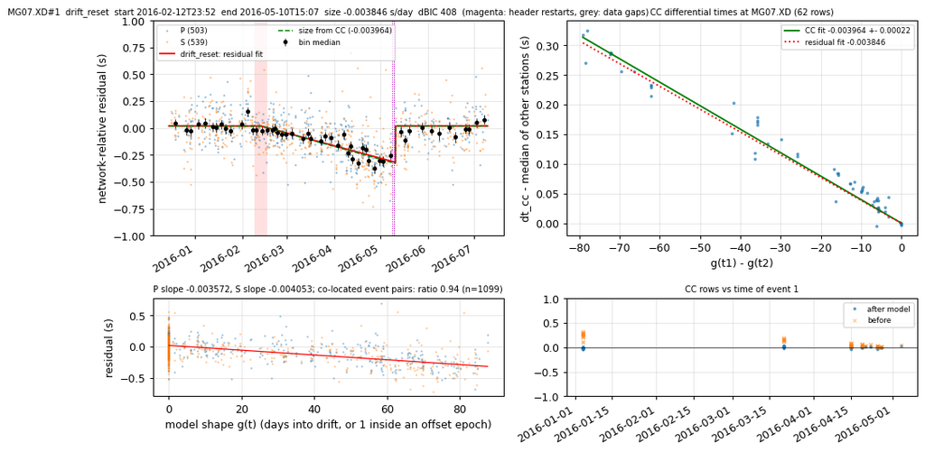

### BB370.X9#1 to review

unclear [P=S] {colocated~0}; start 2012-10-02T08:06:47Z (sd 0.00 d), end 2012-10-12T18:56:43Z [2012-10-12T18:56:40Z .. 2012-10-12T18:56:45Z], restart nan; size -0.12757 +- 0.0053 s (residuals), CC +nan +- nan (n=0); dBIC 365.8, p 0.00498

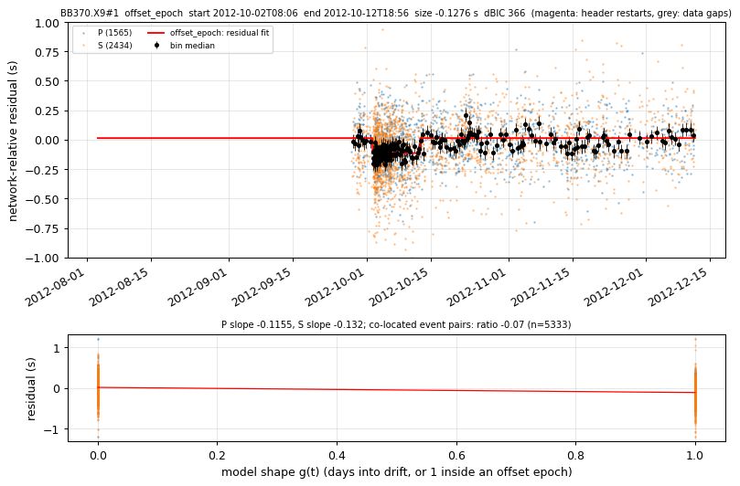

### BB230.X9#1 to review

unclear [P=S] {colocated~0}; start 2012-10-01T21:07:32Z (sd 0.00 d), end 2012-10-04T07:36:59Z [2012-10-04T06:37:18Z .. 2012-10-04T08:36:41Z], restart nan; size +0.52979 +- 0.045 s (residuals), CC +nan +- nan (n=0); dBIC 326.0, p 0.00498

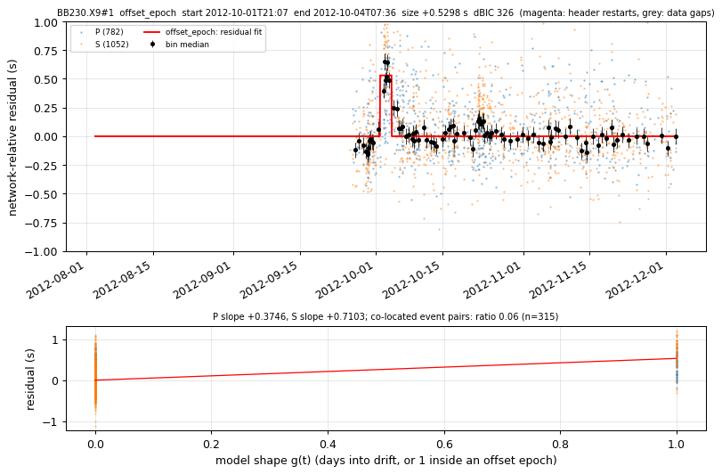

### AXEC2.OO#2 to review

unclear [colocated] {P/S opposite}; start 2014-12-12T01:43:48Z (sd 0.93 d), end 2015-01-04T08:18:46Z [2015-01-04T06:34:35Z .. 2015-01-04T10:02:58Z], restart nan; size -0.023054 +- 0.0017 s/day (residuals), CC +nan +- nan (n=0); dBIC 323.4, p 0.00498

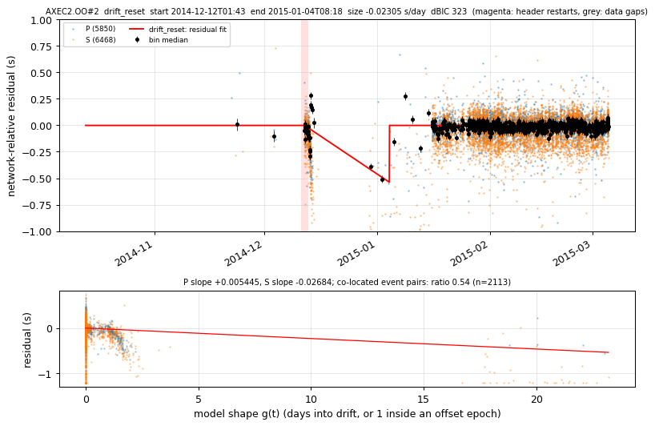

### J06B.7D#1 to review

event-mix-like {colocated~0}; start 2012-10-02T12:38:51Z (sd 0.00 d), end 2012-10-08T18:35:28Z [2012-10-08T18:35:22Z .. 2012-10-08T18:35:34Z], restart nan; size -0.25124 +- 0.016 s (residuals), CC +nan +- nan (n=0); dBIC 304.1, p 0.00498

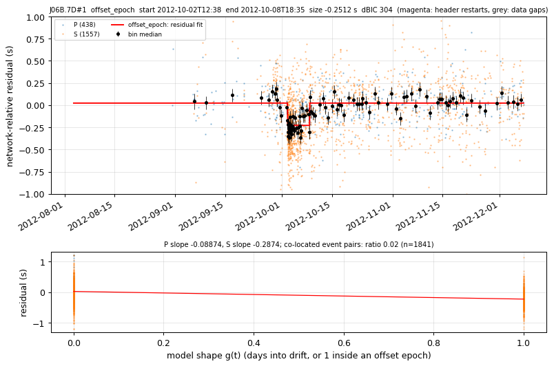

### BB290.X9#1 to review

unclear [P=S] {colocated~0}; start 2012-10-02T15:22:38Z (sd 0.50 d), end 2012-10-06T07:08:43Z [2012-10-06T06:19:12Z .. 2012-10-06T07:58:14Z], restart nan; size +0.37923 +- 0.029 s (residuals), CC +nan +- nan (n=0); dBIC 293.9, p 0.00498

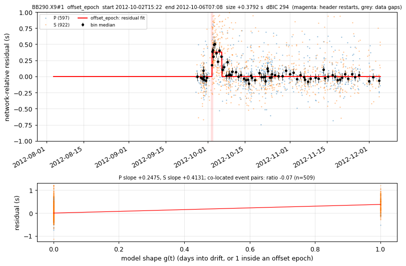

### BB350.X9#1 to review

event-mix-like {colocated~0}; start 2012-09-30T05:26:28Z (sd 4.89 d), end 2012-10-16T01:29:18Z [2012-10-16T01:29:16Z .. 2012-10-16T01:29:21Z], restart nan; size +0.18378 +- 0.11 s (residuals), CC +nan +- nan (n=0); dBIC 280.3, p 0.00498

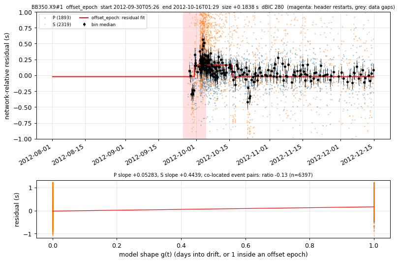

### AXEC1.OO#1 to review

clock-like [colocated,P=S]; start 2014-12-13T22:21:32Z (sd 0.01 d), end 2014-12-16T10:58:45Z [2014-12-16T10:58:36Z .. 2014-12-16T10:58:53Z], restart nan; size -0.083258 +- 0.0066 s (residuals), CC +nan +- nan (n=0); dBIC 273.3, p 0.00498

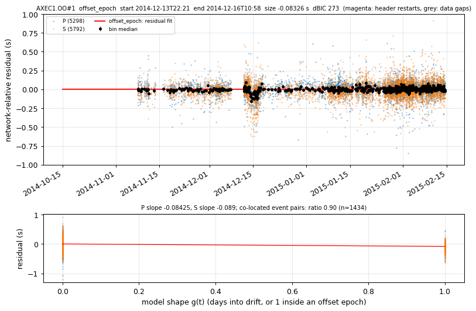

### BB740.Z5#1 to review

unclear [P=S] {colocated~0}; start 2014-03-11T18:07:53Z (sd 0.07 d), end 2014-03-27T18:52:54Z [2014-03-27T18:51:18Z .. 2014-03-27T18:54:30Z], restart nan; size -0.1165 +- 0.0098 s (residuals), CC +nan +- nan (n=0); dBIC 229.2, p 0.00498

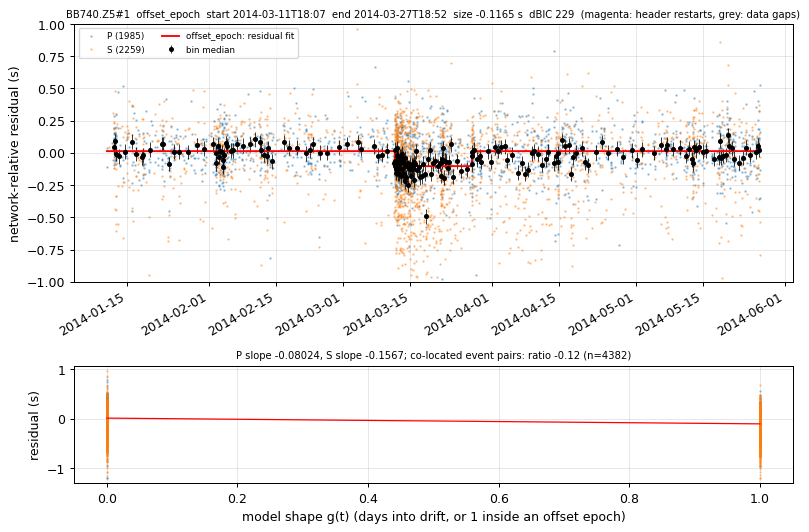

### BB730.Z5#1 to review

unclear [P=S] {colocated~0}; start 2014-03-11T02:15:14Z (sd 2.48 d), end 2014-03-27T18:52:46Z [2014-03-27T18:51:10Z .. 2014-03-27T18:54:22Z], restart nan; size +0.13599 +- 0.0091 s (residuals), CC +nan +- nan (n=0); dBIC 229.0, p 0.00498

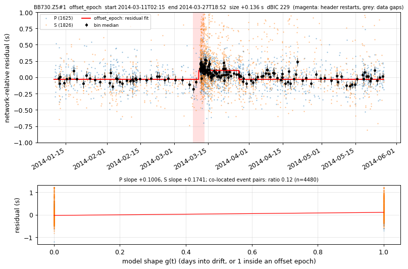

### KCT.NC#2 to review

unclear [colocated]; start 2012-09-16T06:21:26Z (sd 2.98 d), end 2013-05-16T09:54:31Z [2013-05-16T09:54:25Z .. 2013-05-16T09:54:36Z], restart nan; size -0.095209 +- 0.0065 s (residuals), CC +nan +- nan (n=0); dBIC 204.3, p 0.00498

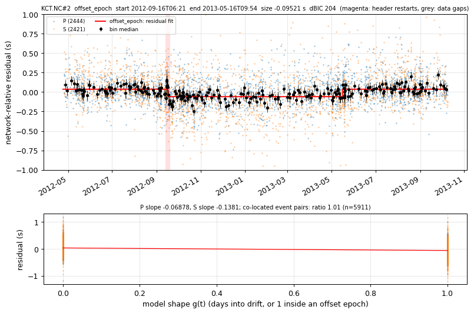

### YACT.UW#1 to review

clock-like [colocated,P=S]; start 2014-07-14T13:55:01Z (sd 4.38 d), end nan [nan .. nan], restart nan; size +0.077465 +- 0.0056 s (residuals), CC +nan +- nan (n=0); dBIC 195.0, p 0.00498

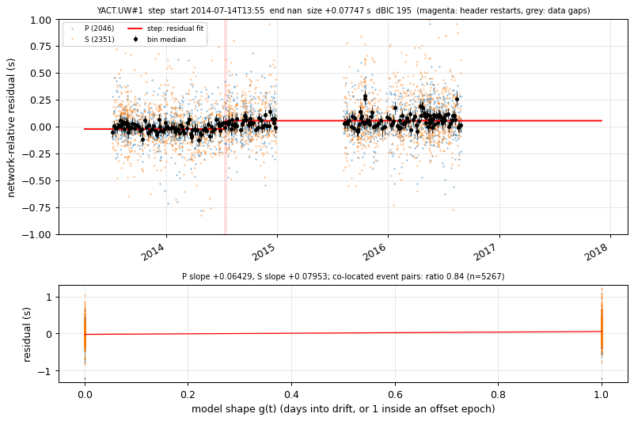

### BB670.Z5#1 to review

event-mix-like {colocated~0}; start 2014-03-11T19:00:34Z (sd 0.00 d), end 2014-03-18T04:26:53Z [2014-03-18T04:10:06Z .. 2014-03-18T04:43:41Z], restart nan; size +0.1553 +- 0.012 s (residuals), CC +nan +- nan (n=0); dBIC 183.4, p 0.00498

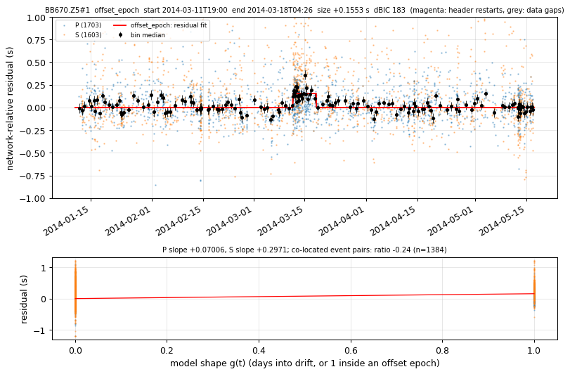

### KCT.NC#1 to review

unclear [colocated]; start 2014-07-23T11:00:23Z (sd 1.80 d), end 2015-07-17T00:43:43Z [2015-07-16T18:41:31Z .. 2015-07-17T06:45:55Z], restart nan; size -0.090025 +- 0.0069 s (residuals), CC +nan +- nan (n=0); dBIC 183.0, p 0.00498

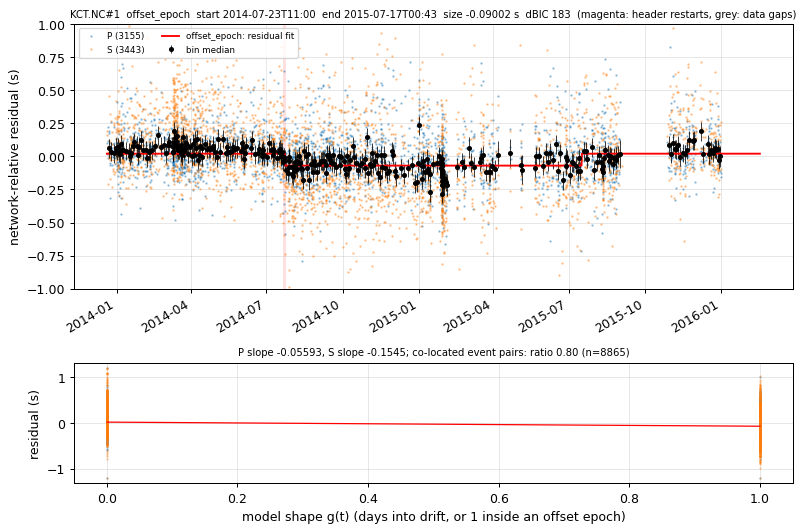

### AXEC3.OO#1 to review

clock-like [colocated,P=S]; start 2014-12-13T23:42:33Z (sd 23.74 d), end 2016-06-27T09:53:36Z [2016-06-27T09:53:36Z .. 2016-06-27T09:53:37Z], restart nan; size -0.00013474 +- 1e-05 s/day (residuals), CC +nan +- nan (n=0); dBIC 183.0, p 0.00498

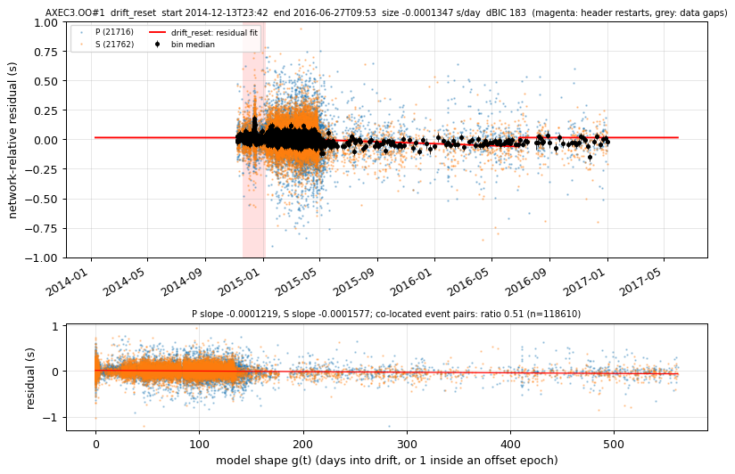

### BB660.Z5#1 to review

event-mix-like {colocated~0}; start 2014-03-11T18:53:36Z (sd 0.52 d), end 2014-03-15T01:50:41Z [2014-03-15T00:13:55Z .. 2014-03-15T03:27:27Z], restart nan; size +0.24105 +- 0.034 s (residuals), CC +nan +- nan (n=0); dBIC 159.4, p 0.00498

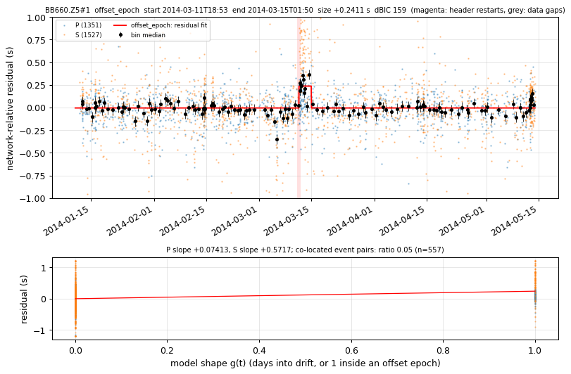

### EDM.UW#1 to review

unclear [colocated,P=S] {CC~0}; start 2013-10-19T00:34:55Z (sd 24.98 d), end nan [nan .. nan], restart nan; size +0.097325 +- 0.0078 s (residuals), CC -0.0023401 +- 0.0022 (n=12); dBIC 157.5, p 0.00498

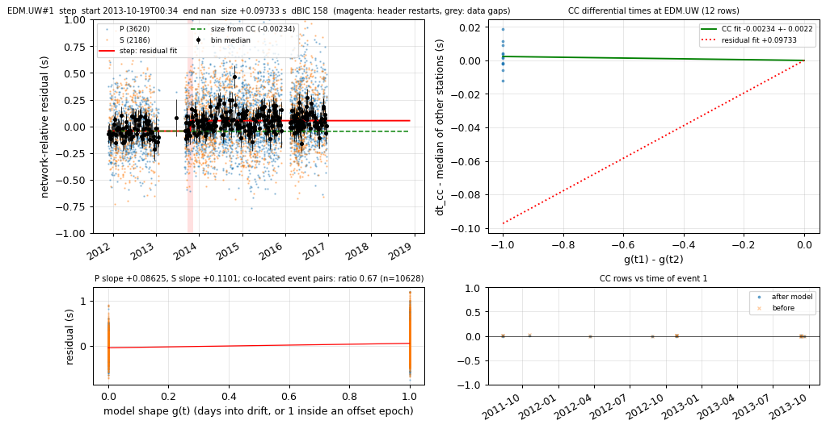

### G04D.7D#1 to review

clock-like [colocated,P=S]; start 2014-12-14T16:54:20Z (sd 0.00 d), end nan [nan .. nan], restart nan; size -0.20596 +- 0.016 s (residuals), CC +nan +- nan (n=0); dBIC 156.8, p 0.00498

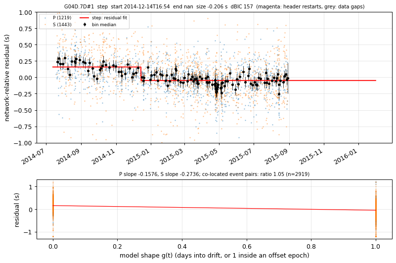

### BB710.Z5#1 to review

event-mix-like {colocated~0}; start 2014-02-01T22:19:45Z (sd 0.00 d), end 2014-02-04T08:34:58Z [2014-02-04T08:31:13Z .. 2014-02-04T08:38:43Z], restart nan; size -0.30301 +- 0.046 s (residuals), CC +nan +- nan (n=0); dBIC 150.0, p 0.00498

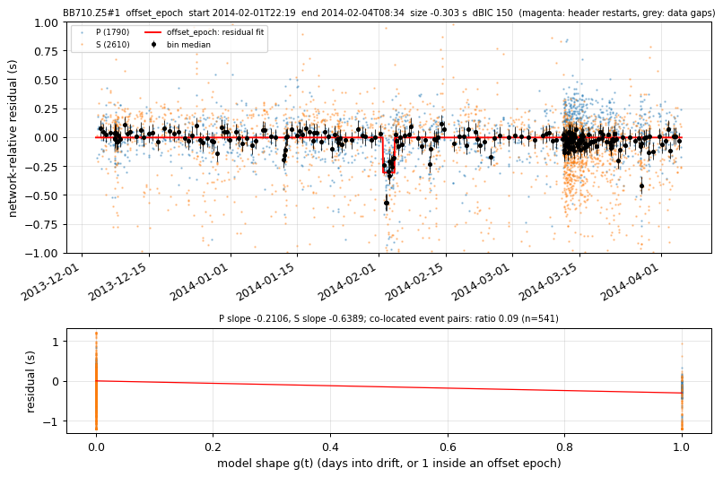

### B049.PB#1 to review

event-mix-like {colocated~0}; start 2014-03-10T05:35:04Z (sd 0.82 d), end 2014-03-21T11:01:12Z [2014-03-21T10:59:09Z .. 2014-03-21T11:03:16Z], restart nan; size +0.1097 +- 0.012 s (residuals), CC +nan +- nan (n=0); dBIC 147.8, p 0.00498

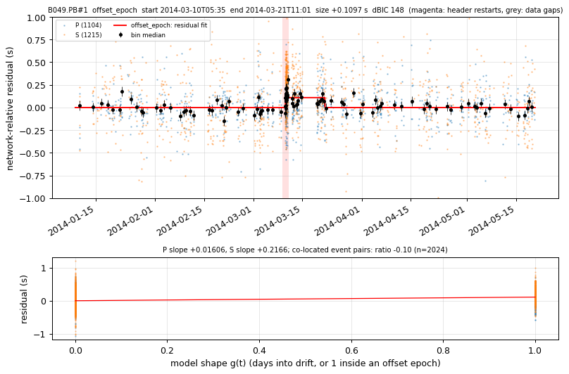

### B201.PB#1 to review

unclear; start 2010-02-19T16:04:06Z (sd 9.31 d), end nan [nan .. nan], restart nan; size -0.28102 +- 0.058 s (residuals), CC +nan +- nan (n=0); dBIC 136.8, p 0.00498

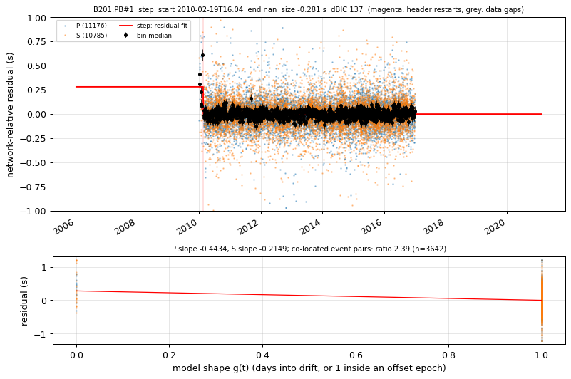

### GB101.Z5#1 to review

unclear [P=S] {colocated~0}; start 2015-04-23T10:29:28Z (sd 0.00 d), end 2015-05-05T16:51:58Z [2015-05-05T16:07:47Z .. 2015-05-05T17:36:09Z], restart nan; size +0.37887 +- 0.057 s (residuals), CC +nan +- nan (n=0); dBIC 135.4, p 0.00498

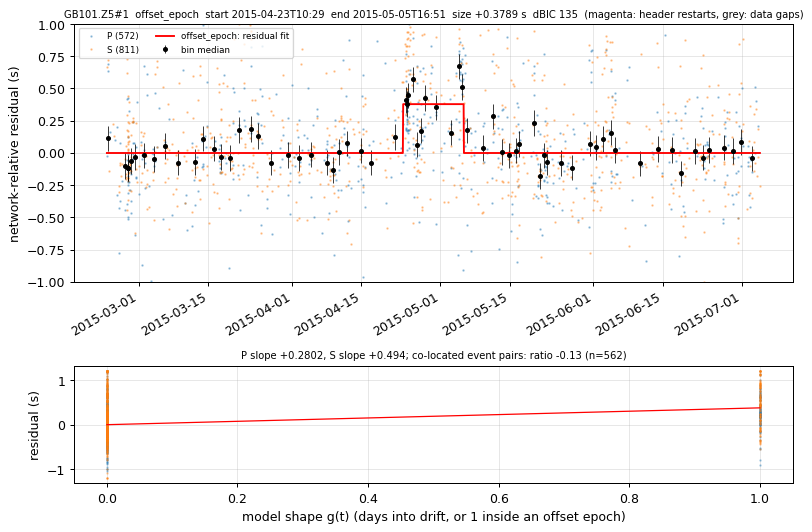

### AXEC3.OO#2 to review

clock-like [colocated,P=S]; start 2014-12-12T04:04:50Z (sd 0.37 d), end 2014-12-14T04:12:57Z [2014-12-14T04:12:57Z .. 2014-12-14T04:12:57Z], restart nan; size +0.061024 +- 0.0088 s/day (residuals), CC +nan +- nan (n=0); dBIC 128.3, p 0.00498

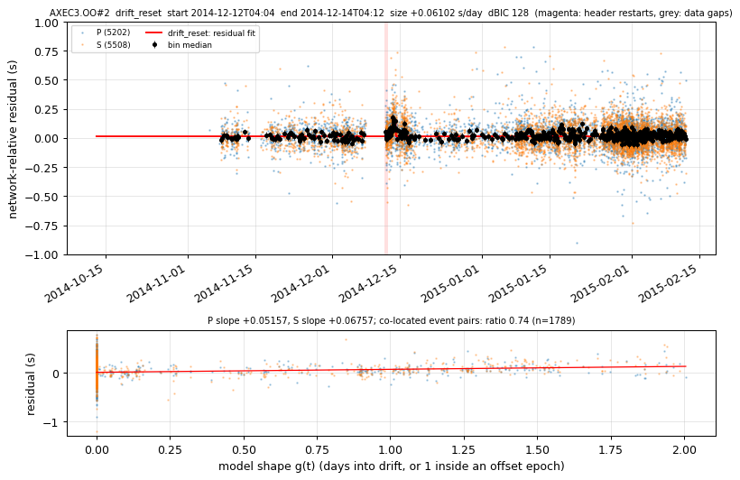

### MA05.XD#1 to review

unclear [P=S] {colocated~0}; start 2016-05-13T15:15:51Z (sd 0.17 d), end 2016-05-16T23:53:31Z [2016-05-16T23:53:18Z .. 2016-05-16T23:53:44Z], restart nan; size +0.13823 +- 0.021 s/day (residuals), CC +nan +- nan (n=0); dBIC 121.5, p 0.00498

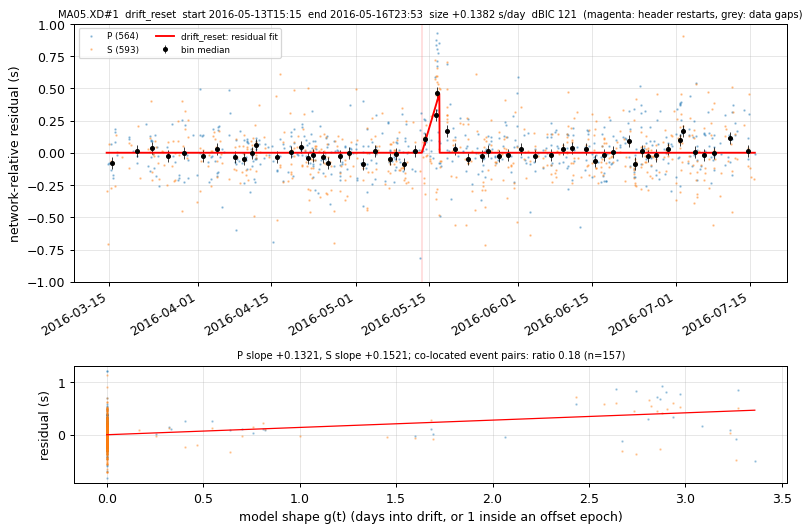

### GB281.Z5#1 to review

clock-like [colocated,P=S]; start 2015-01-03T00:19:52Z (sd 4.55 d), end 2015-08-20T20:33:37Z [2015-08-20T20:30:49Z .. 2015-08-20T20:36:25Z], restart nan; size -0.091827 +- 0.007 s (residuals), CC +nan +- nan (n=0); dBIC 121.3, p 0.00498

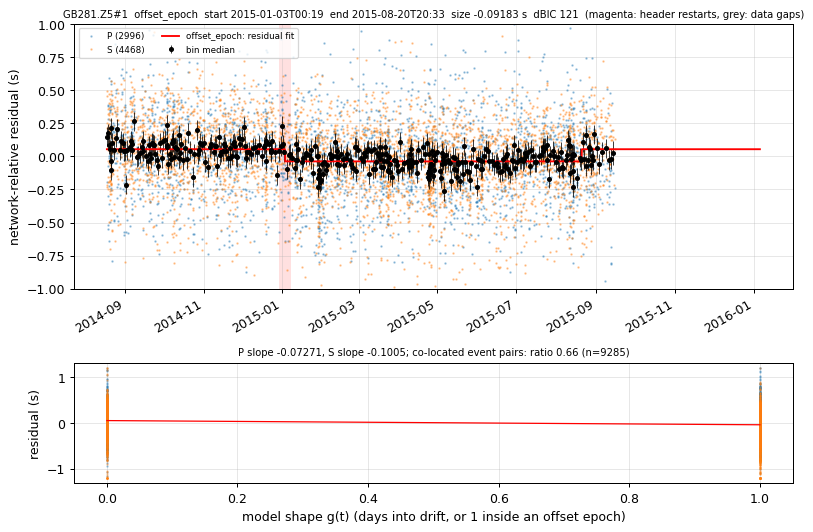

### M02C.TA#1 to review

clock-like [colocated,P=S]; start 2011-05-11T20:49:36Z (sd 9.37 d), end 2015-12-28T06:23:16Z [2015-12-28T04:28:31Z .. 2015-12-28T08:18:01Z], restart nan; size +0.065833 +- 0.0051 s (residuals), CC +nan +- nan (n=0); dBIC 114.7, p 0.00498

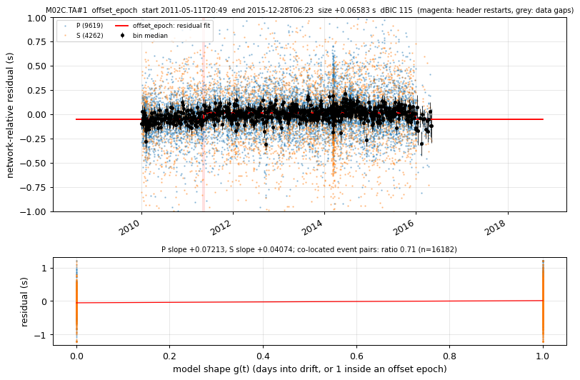

### BB721.Z5#1 to review

event-mix-like {colocated~0}; start 2015-05-31T15:43:06Z (sd 0.04 d), end 2015-06-05T06:20:44Z [2015-06-05T06:18:04Z .. 2015-06-05T06:23:24Z], restart nan; size +0.12847 +- 0.013 s (residuals), CC +nan +- nan (n=0); dBIC 108.8, p 0.00498

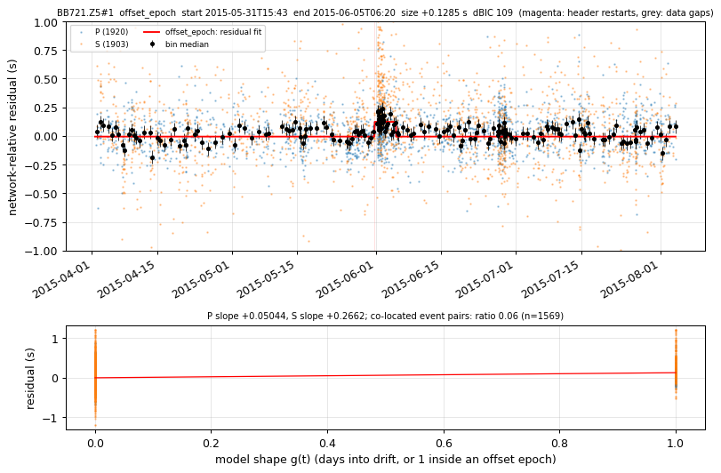

### J29C.7D#1 to review

unclear [P=S] {colocated~0}; start 2014-03-11T05:25:45Z (sd 4.07 d), end 2014-03-22T14:26:53Z [2014-03-22T13:41:43Z .. 2014-03-22T15:12:04Z], restart nan; size +0.26241 +- 0.019 s (residuals), CC +nan +- nan (n=0); dBIC 107.1, p 0.00498

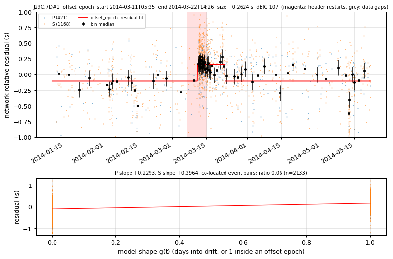

### B203.PB#1 to review

unclear [P=S] {colocated~0}; start 2016-05-16T05:40:57Z (sd 3.85 d), end 2016-05-18T17:32:00Z [2016-05-18T15:13:04Z .. 2016-05-18T19:50:56Z], restart nan; size +0.18019 +- 0.045 s (residuals), CC -0.0046155 +- 0.0015 (n=64); dBIC 103.7, p 0.00498

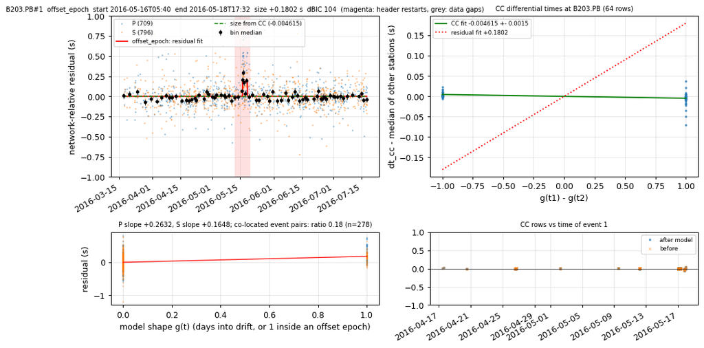

### MN07.XD#1 to review

event-mix-like {colocated~0}; start 2015-05-28T19:18:39Z (sd 143.28 d), end 2015-06-01T23:12:10Z [2015-06-01T23:08:09Z .. 2015-06-01T23:16:11Z], restart nan; size -0.12023 +- 0.068 s/day (residuals), CC +nan +- nan (n=0); dBIC 102.6, p 0.00498

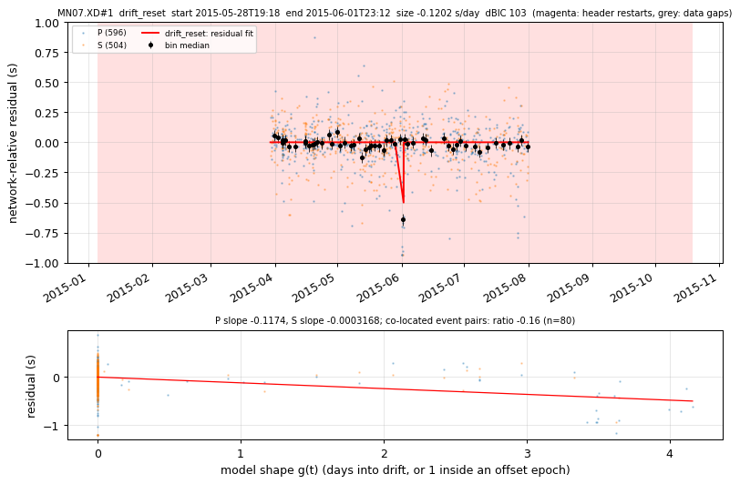

### G02B.7D#1 to review

unclear [P=S]; start 2012-09-22T05:35:27Z (sd 23.34 d), end nan [nan .. nan], restart nan; size -0.0014861 +- 0.00017 s/day (residuals), CC +nan +- nan (n=0); dBIC 99.8, p 0.00498

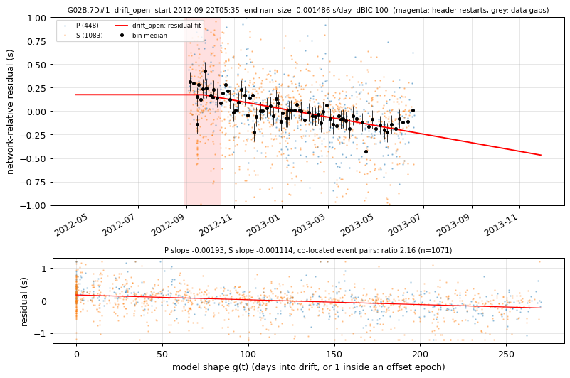

### BLOW.UW#1 to review

event-mix-like {colocated~0}; start 2013-02-28T21:49:19Z (sd 112.20 d), end 2013-03-24T19:29:04Z [2013-03-24T19:28:50Z .. 2013-03-24T19:29:17Z], restart nan; size +0.030404 +- 0.011 s/day (residuals), CC +nan +- nan (n=0); dBIC 97.9, p 0.00498

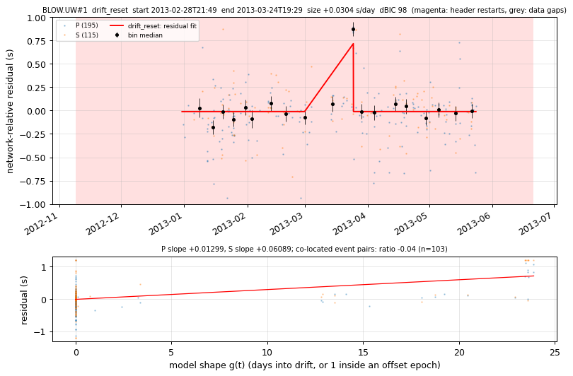

### BB320.X9#1 to review

unclear [P=S]; start 2012-09-30T05:24:49Z (sd 3.73 d), end 2012-10-16T06:50:26Z [2012-10-16T06:44:37Z .. 2012-10-16T06:56:15Z], restart nan; size -0.07989 +- 0.035 s (residuals), CC +nan +- nan (n=0); dBIC 97.8, p 0.00498

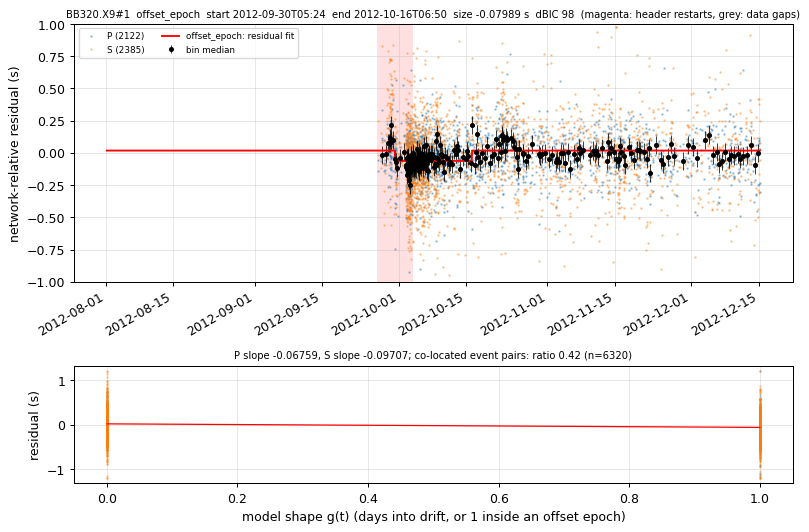

### FL2.UW#1 to review

unclear [P=S]; start 2011-01-25T23:46:58Z (sd 0.88 d), end 2011-06-20T21:58:09Z [2011-06-20T21:58:07Z .. 2011-06-20T21:58:11Z], restart nan; size -0.08994 +- 0.0074 s (residuals), CC +nan +- nan (n=7); dBIC 96.4, p 0.00498

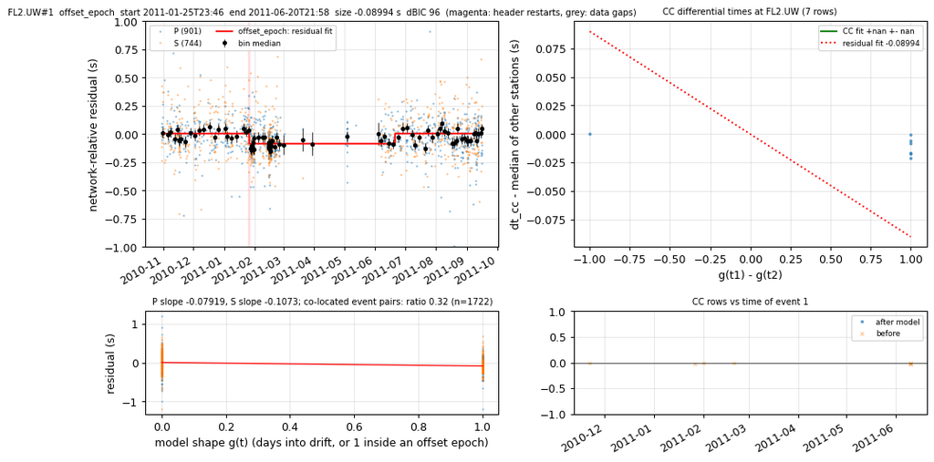

### OZB.CN#1 to review

event-mix-like {colocated~0}; start 2012-02-03T09:57:23Z (sd 27.11 d), end 2012-02-16T13:52:17Z [2012-02-16T10:32:47Z .. 2012-02-16T17:11:47Z], restart nan; size -0.39091 +- 0.055 s (residuals), CC +nan +- nan (n=0); dBIC 94.2, p 0.00498

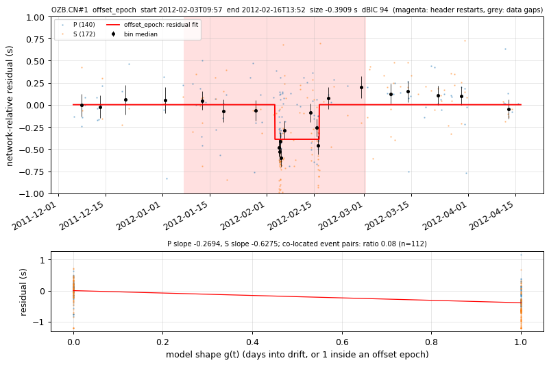

### AXID1.OO#2 to review

clock-like [colocated,P=S]; start 2014-12-13T02:05:42Z (sd 0.17 d), end 2014-12-16T16:12:47Z [2014-12-16T16:12:47Z .. 2014-12-16T16:12:47Z], restart nan; size +0.068759 +- 0.0081 s (residuals), CC +nan +- nan (n=0); dBIC 94.2, p 0.00498

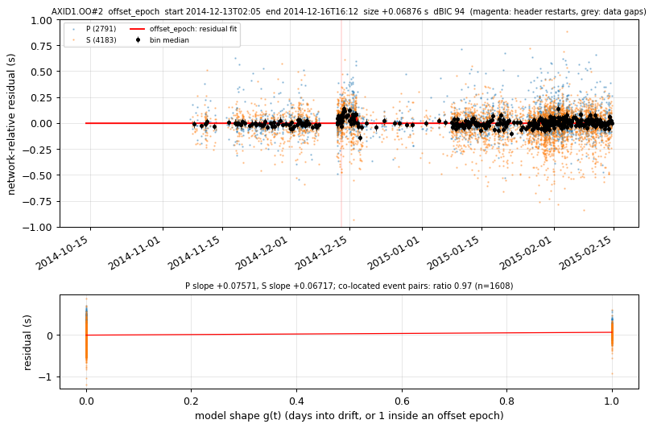

### GB380.Z5#1 to review

unclear; start 2014-03-10T05:38:24Z (sd 0.09 d), end 2014-05-01T10:35:02Z [2014-05-01T10:29:38Z .. 2014-05-01T10:40:25Z], restart nan; size +0.11878 +- 0.011 s (residuals), CC +nan +- nan (n=0); dBIC 93.5, p 0.00498

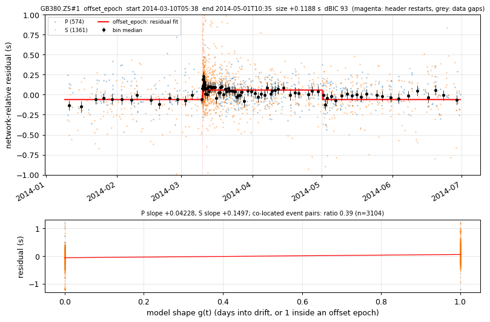

### FS16D.7D#1 to review

event-mix-like {colocated~0}; start 2014-12-31T01:36:46Z (sd 8.72 d), end 2015-02-06T18:44:20Z [2015-02-06T18:44:17Z .. 2015-02-06T18:44:22Z], restart nan; size +0.0072627 +- 0.0026 s/day (residuals), CC +nan +- nan (n=0); dBIC 91.4, p 0.00498

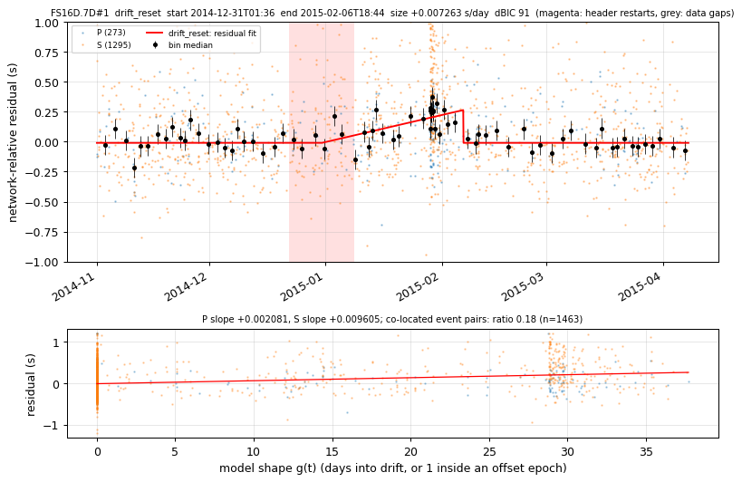

### BB130.X9#1 to review

event-mix-like {colocated~0,P/S opposite}; start 2012-10-02T06:00:19Z (sd 0.61 d), end 2012-10-05T21:04:13Z [2012-10-05T20:51:41Z .. 2012-10-05T21:16:45Z], restart nan; size +0.31964 +- 0.057 s (residuals), CC +nan +- nan (n=0); dBIC 90.8, p 0.00498

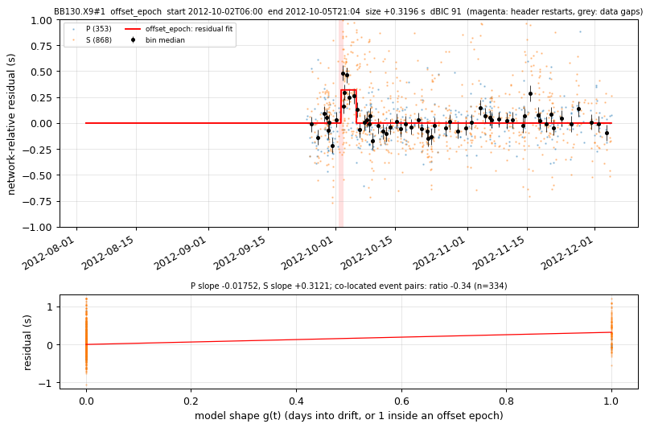

### KHBB.NC#1 to review

unclear; start 2013-04-07T09:36:24Z (sd 66.03 d), end 2014-08-11T05:41:35Z [2014-08-11T03:48:43Z .. 2014-08-11T07:34:28Z], restart nan; size -0.00012306 +- 2.4e-05 s/day (residuals), CC +nan +- nan (n=0); dBIC 90.2, p 0.00498

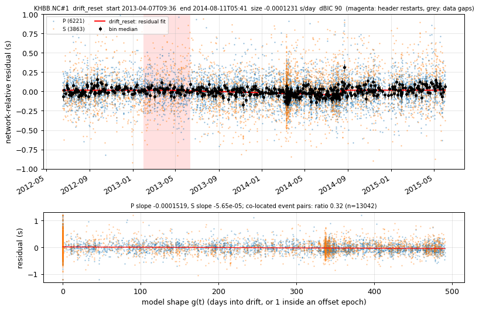

### GB320.Z5#1 to review

clock-like [colocated,P=S]; start 2014-05-21T11:45:18Z (sd 21.86 d), end 2014-09-07T14:10:51Z [2014-09-07T12:35:39Z .. 2014-09-07T15:46:03Z], restart nan; size -0.0015458 +- 0.0059 s/day (residuals), CC +nan +- nan (n=0); dBIC 88.8, p 0.00498

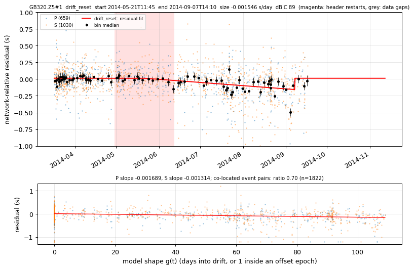

### CDF.UW#1 to review

unclear [colocated] {CC~0}; start 2013-09-28T08:33:29Z (sd 157.65 d), end 2016-09-02T03:18:00Z [2016-09-01T06:43:04Z .. 2016-09-02T23:52:57Z], restart nan; size +6.388e-05 +- 1.2e-05 s/day (residuals), CC +1.0771e-05 +- 6.7e-06 (n=360); dBIC 84.1, p 0.00498

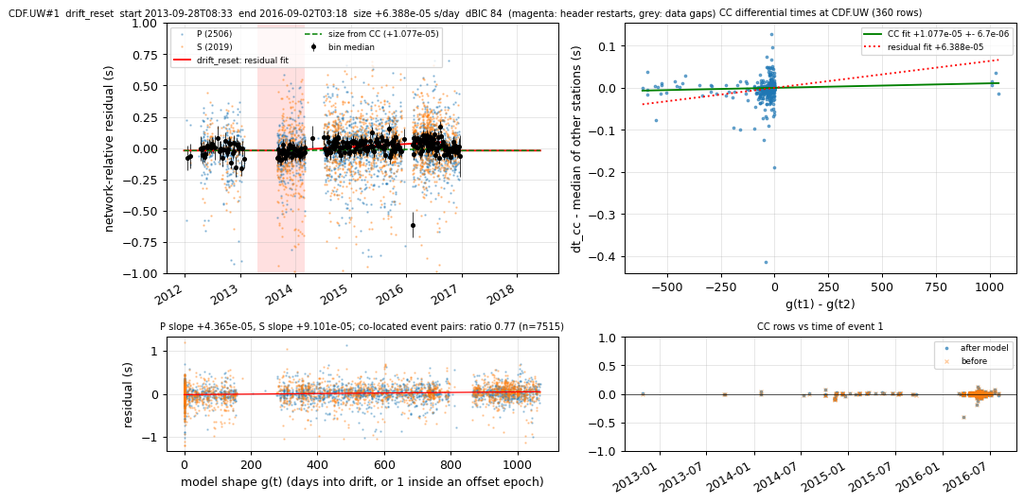

### MGB.CN#1 to review

unclear [P=S] {colocated~0}; start 2012-01-16T23:03:28Z (sd 7.52 d), end 2012-04-01T22:57:22Z [2012-03-27T22:57:18Z .. 2012-04-06T22:57:25Z], restart nan; size -0.19579 +- 0.04 s (residuals), CC +nan +- nan (n=0); dBIC 81.9, p 0.00498

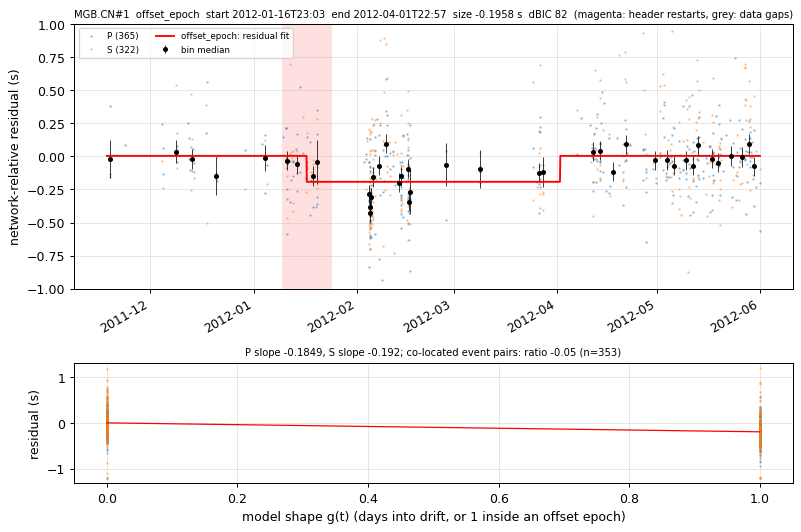

### J35A.7D#1 to review

event-mix-like {colocated~0}; start 2012-05-12T12:00:48Z (sd 7.02 d), end nan [nan .. nan], restart nan; size -0.031277 +- 0.0044 s/day (residuals), CC +nan +- nan (n=0); dBIC 80.8, p 0.00498

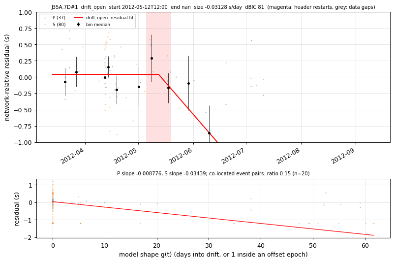

### BB440.X9#1 to review

event-mix-like {colocated~0}; start 2012-09-30T17:47:33Z (sd 1.40 d), end 2012-10-07T23:24:46Z [2012-10-07T23:23:26Z .. 2012-10-07T23:26:06Z], restart nan; size +0.10067 +- 0.039 s (residuals), CC +nan +- nan (n=0); dBIC 79.9, p 0.00498

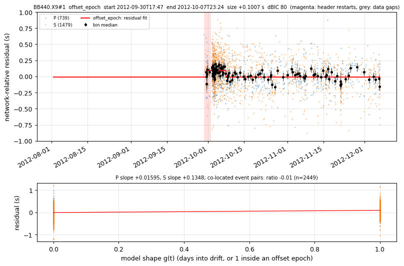

### FS01B.7D#1 to review

clock-like [colocated,P=S]; start 2012-09-22T05:54:27Z (sd 23.00 d), end nan [nan .. nan], restart nan; size +0.00048536 +- 6.9e-05 s/day (residuals), CC +nan +- nan (n=0); dBIC 79.5, p 0.00498

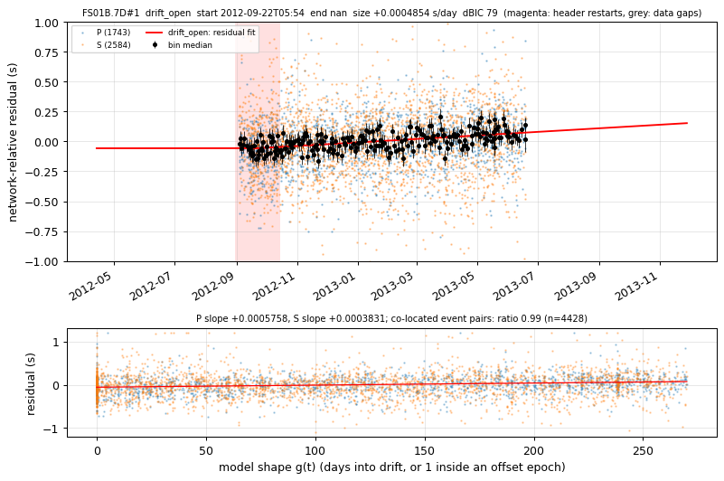

### KSXB.NC#1 to review

event-mix-like {colocated~0}; start 2014-02-07T23:28:03Z (sd 1.02 d), end 2014-05-09T13:46:42Z [2014-05-09T13:46:29Z .. 2014-05-09T13:46:56Z], restart nan; size +0.11969 +- 0.011 s (residuals), CC +nan +- nan (n=0); dBIC 79.1, p 0.00498

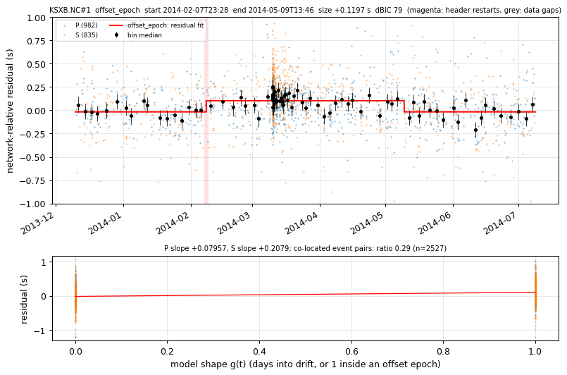

### BB480.X9#1 to review

event-mix-like {colocated~0}; start 2012-10-11T14:08:35Z (sd 2.83 d), end nan [nan .. nan], restart nan; size -0.20822 +- 0.021 s (residuals), CC +nan +- nan (n=0); dBIC 78.5, p 0.00498

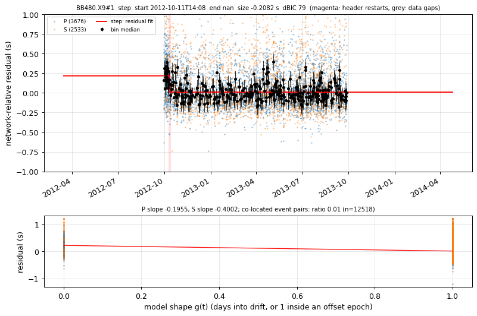

### J63A.7D#1 to review

event-mix-like {colocated~0}; start 2012-01-08T09:08:20Z (sd 0.45 d), end 2012-01-27T09:38:38Z [2012-01-26T13:31:46Z .. 2012-01-28T05:45:29Z], restart nan; size +0.052451 +- 0.0017 s/day (residuals), CC +nan +- nan (n=0); dBIC 78.0, p 0.00498

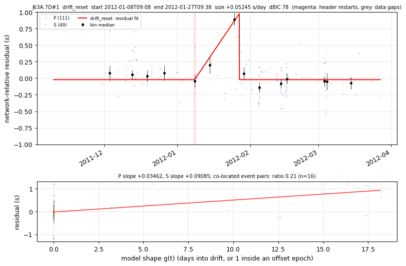

### GB080.Z5#1 to review

event-mix-like {colocated~0,P/S opposite}; start 2014-03-10T06:28:45Z (sd 6.28 d), end 2014-04-26T19:59:12Z [2014-04-26T15:27:39Z .. 2014-04-27T00:30:45Z], restart nan; size -0.13902 +- 0.013 s (residuals), CC +nan +- nan (n=0); dBIC 77.4, p 0.00498

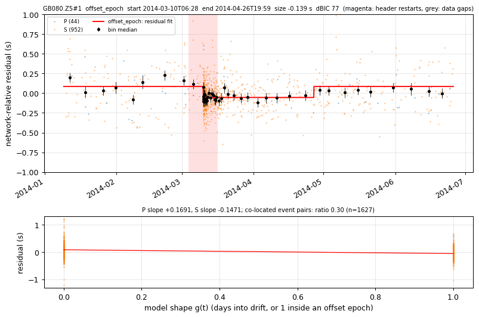

### BB711.Z5#1 to review

unclear; start 2015-03-25T07:25:16Z (sd 7.72 d), end 2015-07-29T20:46:31Z [2015-07-29T20:46:28Z .. 2015-07-29T20:46:34Z], restart nan; size -0.063371 +- 0.0067 s (residuals), CC +nan +- nan (n=0); dBIC 77.3, p 0.00498

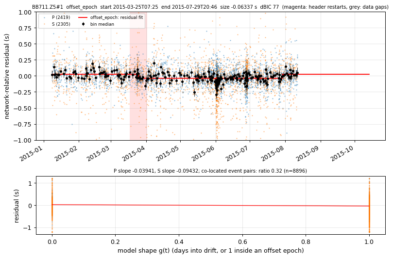

### G35D.7D#1 to review

unclear [P=S] {colocated~0}; start 2015-01-24T14:38:13Z (sd 0.30 d), end 2015-02-03T18:28:59Z [2015-02-03T10:45:25Z .. 2015-02-04T02:12:34Z], restart nan; size -0.11862 +- 0.011 s/day (residuals), CC +nan +- nan (n=0); dBIC 77.0, p 0.00498

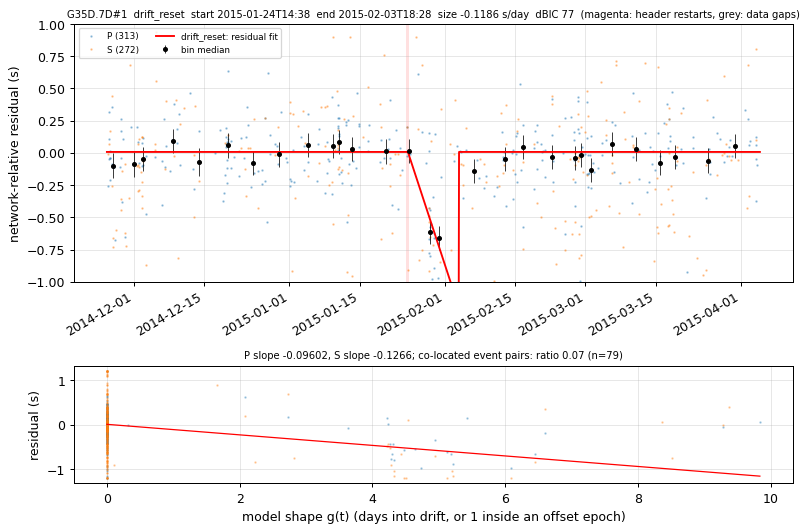

### MP06.XD#1 to review

event-mix-like {colocated~0}; start 2016-05-14T12:49:22Z (sd 0.66 d), end 2016-05-16T13:10:18Z [2016-05-16T13:02:54Z .. 2016-05-16T13:17:43Z], restart nan; size -0.14384 +- 0.029 s/day (residuals), CC +nan +- nan (n=9); dBIC 76.3, p 0.00498

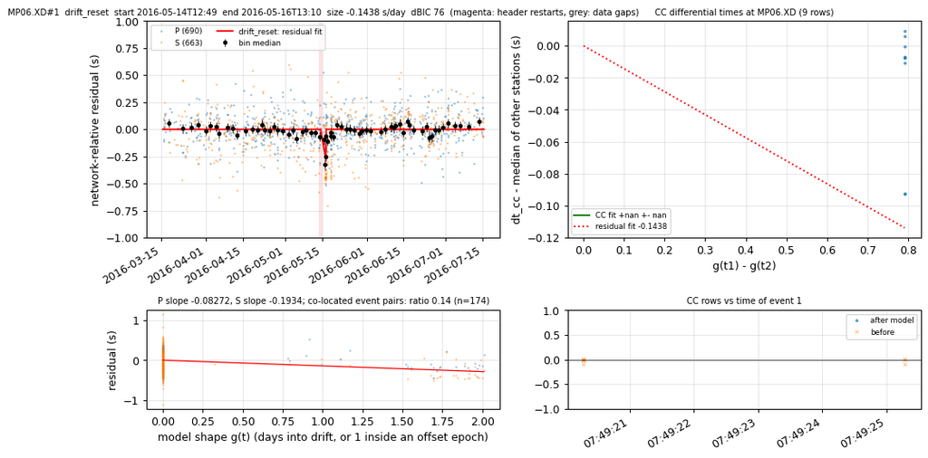

### B202.PB#1 to review

unclear [P=S] {colocated~0}; start 2013-08-01T00:38:16Z (sd 0.00 d), end 2013-09-14T16:06:28Z [2013-09-14T15:31:46Z .. 2013-09-14T16:41:10Z], restart nan; size +0.059676 +- 0.0047 s (residuals), CC +nan +- nan (n=5); dBIC 76.1, p 0.00498

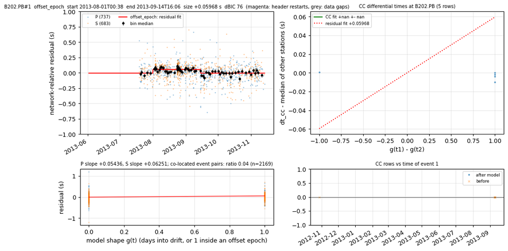